# EP07

# Introducción

En el trabajo de título de una estudiante del DIINF se reportan tiempos de ejecución (en milisegundos) y la cercanía con la solución óptima (en por ciento) de la mejor solución encontrada con tres versiones de un algoritmo genético para resolver instancias del problema del vendedor viajero disponibles en repositorios públicos. Ahora debe enfrentar el análisis de estos datos, por que está solicitando ayuda de las y los estudiantes de Estadística Inferencial.

## Desarrollo

### Pregunta 1

1. Observando los datos, la memorista sospecha que hay diferencias significativas en el tiempo de ejecución entre las versiones B y C del algoritmo cuando las instancias tienen 70 o más nodos. ¿Los datos respaldan la intuición de la memorista?  
   Para responder, filtren los datos para tener las instancias con 70 o más nodos y seleccionen las columnas de los tiempos de ejecución de las versiones B y C en formato ancho. Usando como semilla el valor 13, obtenga muestras aleatorias independientes de 20 tiempos registrados por la versión B y 18 tiempos registrados por la versión C del algoritmo. Realicen un análisis estadístico pertinente (enunciar hipótesis, revisar condiciones, seleccionar pruebas ómnibus y post-hoc según corresponda) para responder la pregunta planteada, utilizando pruebas no paramétricas de ser necesario.

**Hipótesis**

$H_0:$ no existe diferencias significativas en el tiempo de ejecución entre las versiones B y C del algoritmo cuando las instancias tienen 70 o más nodos.

$H_A:$ existe diferencias significativas en el tiempo de ejecución entre las versiones B y C del algoritmo cuando las instancias tienen 70 o más nodos.

```r
data <- read.csv("EP07 Datos.csv")
head(data)
```

```
##   instancia n.nodos n.aristas tiempo.A tiempo.B tiempo.C mejor.A mejor.B
## 1         1      50       631   107534   452595   257485   98.72   98.25
## 2         2      50       521    74808   364061   207297   98.99   99.17
## 3         3      50       588    94072   417798   237793   99.10   99.23
## 4         4      50       653   114830   470701   267598   98.69   99.23
## 5         5      50       597    96720   425233   241770   99.80   99.22
## 6         6      50       564    86688   398448   226833   99.19   99.15
##   mejor.C
## 1   99.34
## 2   99.48
## 3   99.10
## 4   97.82
## 5   98.14
## 6   98.04
```

```r
library(dplyr)
# filtrar numero de nodos 70
data_filtrada <- data |>
  filter(n.nodos >=70)

# formato ancho de la tabla
datos_anchos <- data.frame(n.nodos = data_filtrada[["n.nodos"]], tiempo.B = data_filtrada[["tiempo.B"]], tiempo.C = data_filtrada[["tiempo.C"]])

head(datos_anchos)
```

```
##   n.nodos tiempo.B tiempo.C
## 1      70   947924   536924
## 2      70   965334   547148
## 3      70   854179   484068
## 4      70   990491   560973
## 5      70   985163   557996
## 6      70   891077   505090
```

```r
set.seed(13)

# Escoger 20 y 18 muestras respectivamente
muestras_aleatorias_B <- sample(datos_anchos[["tiempo.B"]], 20)
muestras_aleatorias_C <- sample(datos_anchos[["tiempo.C"]], 18)

# verificar normalidad
shapiro_B <- shapiro.test(muestras_aleatorias_B)
shapiro_C <- shapiro.test(muestras_aleatorias_C)

shapiro_B
```

```
##
##  Shapiro-Wilk normality test
##
## data:  muestras_aleatorias_B
## W = 0.87881, p-value = 0.01684
```

```r
shapiro_C
```

```
##
##  Shapiro-Wilk normality test
##
## data:  muestras_aleatorias_C
## W = 0.96977, p-value = 0.7933
```

Considerando un nivel de significancia de $\alpha = 0.05$, notamos que las muestras aleatoria de **B** entrega $p.value = 0.01684$ el cual es menor al alfa, por lo que se concluye que la muestra B no sigue una distribución normal

```r
library(ggpubr)
```

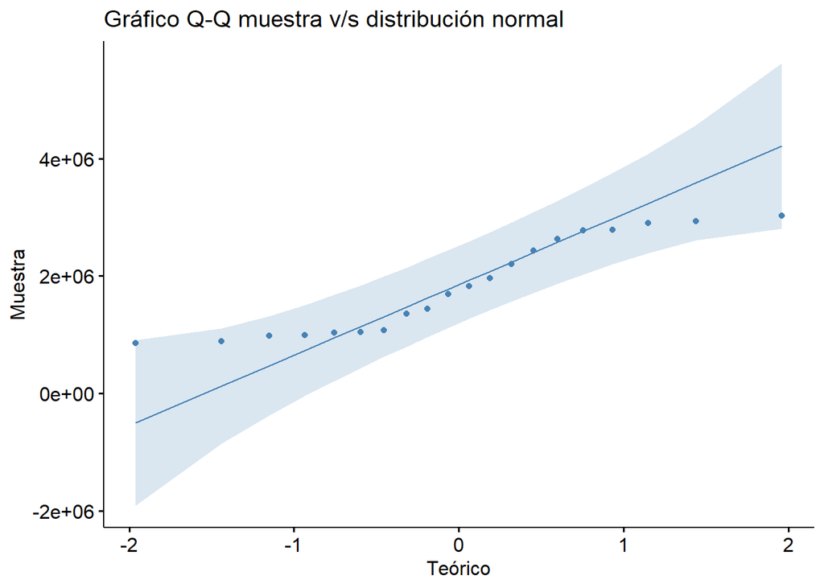

```r
ggqqplot(data = data.frame(muestras_aleatorias_B), x = "muestras_aleatorias_B", title = "Gráfico Q-Q muestra v/s distribución normal", xlab = "Teórico", ylab = "Muestra", color= "steelblue", alpha = 0.7)
```

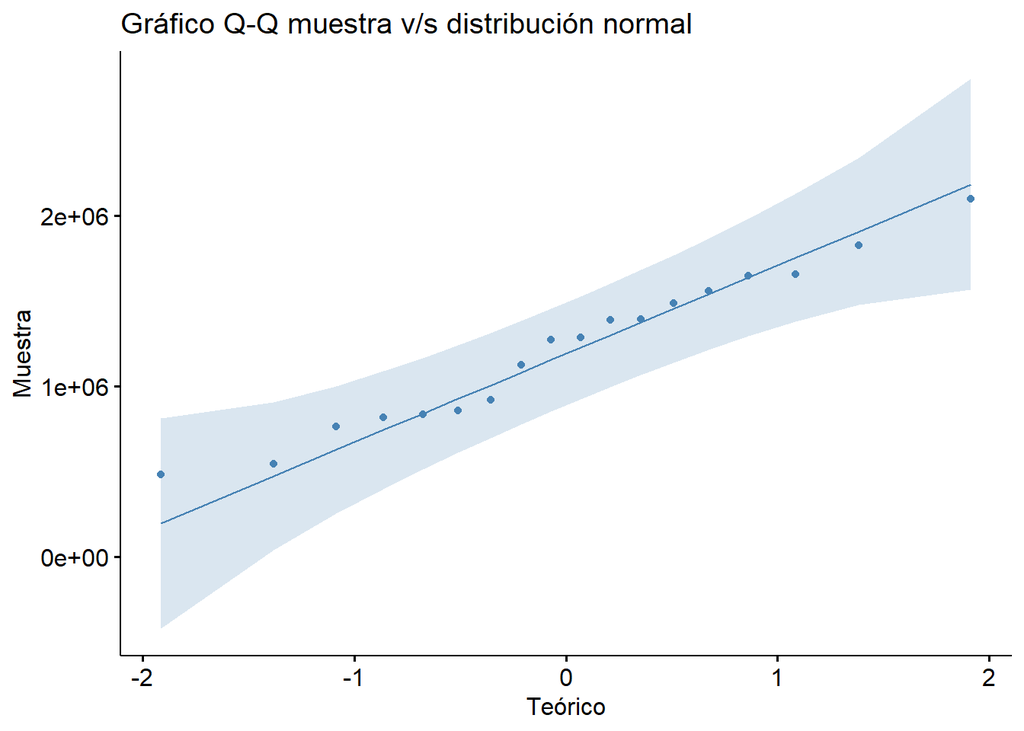

```r
ggqqplot(data = data.frame(muestras_aleatorias_C), x = "muestras_aleatorias_C", title = "Gráfico Q-Q muestra v/s distribución normal", xlab = "Teórico", ylab = "Muestra", color= "steelblue", alpha = 0.7)
```

En los gráficos se puede notar que ambas muestras aleatorias de los grupos de tiempo B y C, siguen una distribución normal y no se observa a simple vista datos atípicos.

Continuando con las condiciones:

1. Las observaciones de las muestras son independientes ya que, se escogieron 20 y 18 muestras aleatorias de los grupos B y C respectivamente.

```r
prueba <- wilcox.test(muestras_aleatorias_B, muestras_aleatorias_C, alternative = "two.sided", conf.level = 0.95)
prueba
```

```
##
##  Wilcoxon rank sum exact test
##
## data:  muestras_aleatorias_B and muestras_aleatorias_C
## W = 262, p-value = 0.01592
## alternative hypothesis: true location shift is not equal to 0
```

Finalmente, luego de realizar el test de Shapiro para verificar la normalidad de los datos, se identificó que los tiempos de B no siguen una distribución normal. Por esta razón, se decidió utilizar la prueba de Wilcox (no paramétrica).

Este test nos entregó un $p-value=0.01592$. Considerando un nivel de significancia $\alpha = 0.05$, existe evidencia para rechazar la hipótesis nula.

En conclusión, los datos respaldan la intuición del memorista ya que, se encontraron diferencia en los tiempos de ejecución de las versiones B y C

### Pregunta 2

2. La memorista también sospecha que, al comparar las mismas instancias de iguales características, las mejores soluciones encontradas por las versiones A y C tienen rendimientos distintos. ¿Estará en lo cierto? Para responder, filtren los datos para tener las instancias con 70 o más nodos y seleccionen las columnas con el mejor rendimiento de las versiones A y C en formato ancho. Usando como semilla el valor 13, obtengan una muestra aleatoria de 24 instancias. Realicen un análisis estadístico pertinente (enunciar hipótesis, revisar condiciones, seleccionar pruebas ómnibus y post-hoc según corresponda) para responder la pregunta planteada, utilizando pruebas no paramétricas de ser necesario.

Las hipótesis a trabajar:

$H_0:$ Las mejores soluciones encontradas por las versiones A y C tienen rendimientos iguales.

$H_A:$ Las mejores soluciones encontradas por las versiones A y C tienen rendimientos distintos.

```r
# filtrar para tener las instancias con 70 o más nodos
# reutilizado de la pregunta anterior data_filtrada

# columnas con mejor rendimiento de las versiones A y C en formato ancho:

mejores <- data_filtrada |>
  select(mejor.A, mejor.C)

# semilla 13
set.seed(13)
indices_aleatorios <- sample(1:nrow(mejores), 24)
muestra_pareada <- mejores[indices_aleatorios, ]

diferencia <- muestra_pareada$mejor.A - muestra_pareada$mejor.C

shapiro.test(diferencia)
```

```
##
##  Shapiro-Wilk normality test
##
## data:  diferencia
## W = 0.95577, p-value = 0.3594
```

Verificar si las muestras siguen una distribución normal

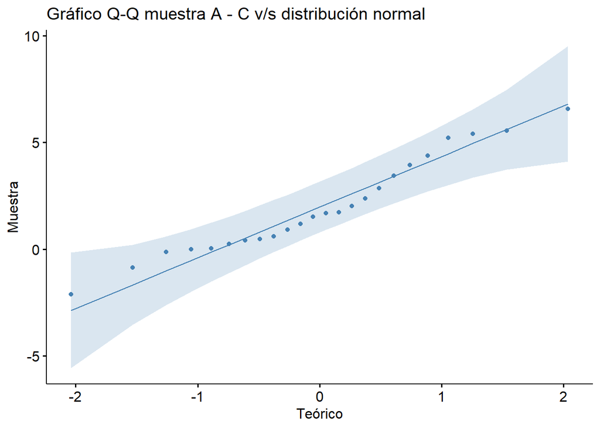

```r
qq1 <- ggqqplot(data = data.frame(diff=diferencia), x = "diff", title = "Gráfico Q-Q muestra A - C v/s distribución normal", xlab = "Teórico", ylab = "Muestra", color= "steelblue", alpha = 0.7)

qq1
```

A simple vista, se puede notar que efectivamente los datos son normales.

```r
t.test(muestra_pareada$mejor.A, muestra_pareada$mejor.C, paired = TRUE, alternative = "two.sided")
```

```
##
##  Paired t-test
##
## data:  muestra_pareada$mejor.A and muestra_pareada$mejor.C
## t = 4.291, df = 23, p-value = 0.0002726
## alternative hypothesis: true mean difference is not equal to 0
## 95 percent confidence interval:
##  1.024593 2.932074
## sample estimates:
## mean difference
##        1.978333
```

Luego de realizar prueba de normalidad de Shapiro, se concluye que los datos siguen una distribución normal, por lo que se decide por utilizar una prueba T test.

Este test entregó un $p-value = 0.0002725$, el cual es muy inferior al nivel de significancia establecido ($\alpha = 0.05$) $p-value < 0.05$. Finalmente se concluye que existe evidencia para rechazar la hipótesis nula en favor de la hipótesis alternativa.

### Pregunta 3

3. La memorista sospecha que hay diferencias significativas en el tiempo de ejecución entre las versiones del algoritmo cuando las instancias de prueba tienen 50 o más nodos. ¿Los datos respaldan la intuición de la memorista?  
   Para responder, filtren los datos para tener las instancias con 50 o más nodos y seleccionen las columnas con los tiempos de ejecución registrados (en formato ancho). Usando como semilla el valor 54, obtengan muestras aleatorias independientes de 12, 13 y 14 tiempos registrados por las versiones A, B y C, respectivamente. Realicen un análisis estadístico pertinente (enunciar hipótesis, revisar condiciones, seleccionar pruebas ómnibus y post-hoc según corresponda) para responder la pregunta planteada, utilizando pruebas no paramétricas de ser necesario.

Primero se filtran los datos para cumplir el requerimiento de 50 nodos o más:

```r
library(dplyr)
# Filtrar número de nodos 50
data_50 <- data |>
  filter(n.nodos >=50)

# formato ancho de la tabla
datos_anchos_50 <- data.frame(n.nodos = data_50[["n.nodos"]], tiempo.A= data_50[["tiempo.A"]],tiempo.B = data_50[["tiempo.B"]], tiempo.C = data_50[["tiempo.C"]])

head(datos_anchos_50)
```

```
##   n.nodos tiempo.A tiempo.B tiempo.C
## 1      50   107534   452595   257485
## 2      50    74808   364061   207297
## 3      50    94072   417798   237793
## 4      50   114830   470701   267598
## 5      50    96720   425233   241770
## 6      50    86688   398448   226833
```

Luego se seleccionan muestras aleatorias de los datos ya filtrados, de tamaño 12, 13 y 14 tiempos registrados por las versiones A, B y C, respectivamente.

```r
set.seed(54)

# Se escogen muestras aleatorias
muestra_A <- sample(datos_anchos_50$tiempo.A, 12)
muestra_B <- sample(datos_anchos_50$tiempo.B, 13 )
muestra_C <- sample(datos_anchos_50$tiempo.C, 14)
```

Ya con las muestras seleccionadas, se formulan las siguientes hipótesis:

- $H_{0}$: No existen diferencias significativas en las medias de tiempo de ejecución entre las versiones del algoritmo.
- $H_{A}$: Al menos una de las versiones reporta una media de tiempo de ejecución diferente a las reportadas por alguna otra versión.

Por las muestras y las hipótesis, se debería usar un test ANOVA de una vía para muestras independientes, pues solo se cuenta con una variable independiente, en este caso, la versión del algoritmo (A, B o C), pero no será tan robusta ya que las muestras difieren de tamaño.

La condición de que la variable dependiente sigue una escala de intervalos iguales se cumple al ser una medida estandarizada física [ms], las muestras fueron elegidas aleatoriamente, por lo que se puede suponer independencia.

Ahora se debe comprobar que las poblaciones siguen una distribución normal, para ello primero se construyen gráficos Q-Q para cada muestra:

```r
library(car)
```

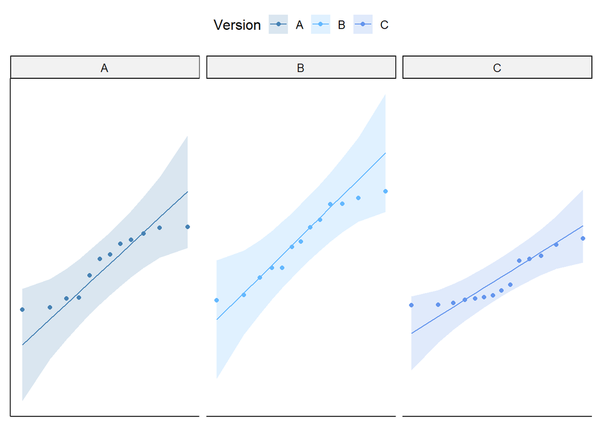

```r
# Se construye el dataframe respectivo
Tiempo <- c(muestra_A, muestra_B, muestra_C)
Version <- c(rep("A", length(muestra_A)), rep("B", length(muestra_B)), rep("C", length(muestra_C)))

Version <- factor(Version)

data_muestra <- data.frame(Tiempo, Version)

# Se construyen los gráficos Q-Q para cada muestra
g1 <- ggqqplot (data_muestra, x = "Tiempo", y = "Version",
color = "Version", alpha = 0.7,
palette = c("steelblue", "steelblue1", "cornflowerblue", "steelblue4") )
g1 <- g1 + facet_wrap(~ Version)
g1 <- g1 + rremove ("x.ticks") + rremove ("x.text")
g1 <- g1 + rremove ("y.ticks") + rremove ("y.text")
g1 <- g1 + rremove ("axis.title")
print (g1)
```

Aunque los datos no están fuera de el intervalo de confianza, se confirmara la normalidad por medio de test de Shapiro-Wilk

```r
shap_A <- shapiro.test(muestra_A)
shap_A
```

```
##
##  Shapiro-Wilk normality test
##
## data:  muestra_A
## W = 0.88469, p-value = 0.1007
```

```r
shap_B <- shapiro.test(muestra_B)
shap_B
```

```
##
##  Shapiro-Wilk normality test
##
## data:  muestra_B
## W = 0.93239, p-value = 0.3661
```

```r
shap_C <- shapiro.test(muestra_C)
shap_C
```

```
##
##  Shapiro-Wilk normality test
##
## data:  muestra_C
## W = 0.84363, p-value = 0.01822
```

Según los test realizados a cada muestra, la muestra de la versión C no proviene de una población que siga una distribución normal, por ello no se puede utilizar la prueba ANOVA de una vía para muestras independientes.

Con esto en cuenta, se optará por realizar una prueba no paramétrica de Kruskal-Wallis.

Con ello se reformulan las hipótesis para la prueba no paramétrica:

- $H_{0}$: No existen diferencias significativas en el tiempo de ejecución entre las versiones del algoritmo.
- $H_{A}$: Al menos una de las versiones reporta un tiempo de ejecución diferente a las reportadas por alguna otra versión.

Ahora se debe corroborar que se cumplan las condiciones para la prueba:

- La escala de la variable dependiente debe ser, a lo menos, ordinal: Como se comprobó anteriormente se cumple, aunque el tiempo no sea ordinal se cumple que hay una escala u orden donde por ejemplo 2s>1s.
- Las observaciones son independientes: Ya comprobado anteriormente.
- La variable independiente debe tener a lo menos 2 niveles: Se cuenta con 3 niveles para la variable independiente Versión (A, B y C).

Ya con las hipótesis formuladas y las condiciones verificadas, con un $\alpha=0.05$ se procede a realizar la prueba de Kruskal-Wallis:

```r
kruskal.test(Tiempo ~ Version, data_muestra)
```

```
##
##  Kruskal-Wallis rank sum test
##
## data:  Tiempo by Version
## Kruskal-Wallis chi-squared = 7.5986, df = 2, p-value = 0.02239
```

Los resultados dados por la prueba indican un $p<0.05$, por lo que se rechaza la hipótesis nula en favor de la alternativa, significando que existe al menos una versión que reporta un tiempo de ejecución diferente a las reportadas por las otras versiones. Para averiguar donde se produce esta diferencia, se realizará una prueba Post-Hoc.

Se realizará un procedimiento Post-Hoc de Benjamini y Hochberg, al no necesitar hacer comparaciones adicionales como para utilizar Scheffe y no cumplir los requisitos para HSD de Tukey (grupos con misma cantidad de observaciones).

```r
bh <- pairwise.wilcox.test(data_muestra[["Tiempo"]], data_muestra[["Version"]], p.adjust.method = "BH", paired=FALSE, exact=FALSE)
bh
```

```
##
##  Pairwise comparisons using Wilcoxon rank sum test with continuity correction
##
## data:  data_muestra[["Tiempo"]] and data_muestra[["Version"]]
##
##   A     B
## B 0.202 -
## C 0.208 0.025
##
## P value adjustment method: BH
```

Utilizando un $\alpha=0.05$, con los resultados del Post-Hoc se determina que existe una diferencia significativa entre las versiones B y C del algoritmo, esto por el valor $p<\alpha$ dado por la prueba.

Como conclusión, existe una diferencia significativa en el tiempo de ejecución de las versiones del algoritmo, específicamente, las versiones B y C presentan esta diferencia.

### Pregunta 4

4.La memorista también sospecha que, al comparar las mismas instancias con iguales características, las mejores soluciones encontradas por las diferentes versiones del algoritmo tienen rendimientos distintos. ¿Estará en lo cierto?  
Para responder, filtren los datos para tener las instancias con 50 o más nodos y seleccionen las columnas con los mejores rendimientos registrados. Usando como semilla el valor 54, obtengan una muestra aleatoria de 22 instancias. Realicen un análisis estadístico pertinente (enunciar hipótesis, revisar condiciones, seleccionar pruebas ómnibus y post-hoc según corresponda) para responder la pregunta planteada, utilizando pruebas no paramétricas de ser necesario.

Primero se utilizan los datos previamente filtrados con un cantidad de nodos mayores o iguales a 50, y se prepara una muestra aleatoria de 22 instancias.

```r
data_best50 <- data.frame(n.nodos = data_50[["n.nodos"]], mejor.A= data_50[["mejor.A"]],mejor.B = data_50[["mejor.B"]], mejor.C = data_50[["mejor.C"]])

set.seed(54)
muestra_aleatoria <- sample(1:nrow(data_best50), 22)
muestra_par <- data_best50[muestra_aleatoria,]
```

Ya con la muestra formulamos las hipótesis:

- $H_{0}$: Las mejores soluciones encontradas por las diferentes versiones del algoritmo no presentan diferencias significativas en su rendimiento.
- $H_{A}$: Las mejores soluciones encontradas por las diferentes versiones del algoritmo presentan diferencias significativas en su rendimiento en por lo menos dos de ellos.

Teniendo en cuenta las hipótesis y los datos, se puede considerar una prueba ANOVA de una vía para muestras correlacionadas, al presentarse un diseño con medidas repetidas, en donde una instancia es medida 3 veces por distintas versiones del algoritmo.

Se procede a comprobar las condiciones para la prueba:

- Variable dependiente con escala de intervalos iguales: A pesar de que se mide en porcentaje, esto no significa que sea de intervalos iguales, pues no se sabe cómo es que se asigna y mide este porcentaje en la mejor solución dada, por lo que no se puede estar seguro de que se cumpla esta condición.
- Observaciones independientes al interior de cada muestra: las observaciones (instancias) se puede suponer son independientes, pues fueron obtenidas de repositorios públicos y se supone que no tienen relación entre si más allá del problema del vendedor viajero.
- Se puede suponer que las poblaciones siguen una distribución normal:

Para analizar esta condición, primero se armarán gráficos Q-Q para cada muestra

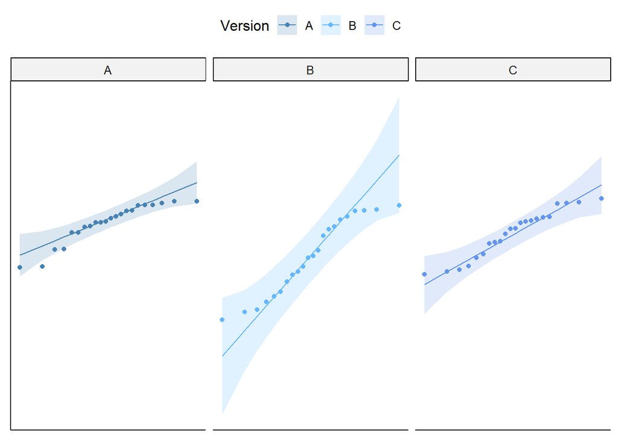

```r
library(tidyr)
library(ggpubr)

# Se transforman los datos a largo
muestra_par_largo <- muestra_par |>
  pivot_longer(cols = c(mejor.A, mejor.B, mejor.C),
               names_to = "Version",
               values_to = "Mejor") |>
  mutate(Version = factor(gsub("mejor\\.", "", Version)))

# Se construyen los gráficos
g2 <- ggqqplot(muestra_par_largo,
               x = "Mejor",
               color = "Version",
               alpha = 0.7,
               palette = c("steelblue", "steelblue1", "cornflowerblue")) +
  facet_wrap(~ Version)
g2 <- g2 + rremove ("x.ticks") + rremove ("x.text")
g2 <- g2 + rremove ("y.ticks") + rremove ("y.text")
g2 <- g2 + rremove ("axis.title")

print(g2)
```

En los gráficos construidos se pueden ver algunos valores atípicos en la versión A, se confirmará la normalidad mediante test Shapiro-Wilk

```r
# Versión A
shapiro.test(muestra_par$mejor.A)
```

```
##
##  Shapiro-Wilk normality test
##
## data:  muestra_par$mejor.A
## W = 0.88109, p-value = 0.01268
```

```r
# Versión B
shapiro.test(muestra_par$mejor.B)
```

```
##
##  Shapiro-Wilk normality test
##
## data:  muestra_par$mejor.B
## W = 0.92676, p-value = 0.105
```

```r
# Version C
shapiro.test(muestra_par$mejor.C)
```

```
##
##  Shapiro-Wilk normality test
##
## data:  muestra_par$mejor.C
## W = 0.93657, p-value = 0.1681
```

Usando los resultados de los test para cada muestra, se puede observar que para la versión A el p value es menor al alpha que usamos 0.05, por lo cual su población no sigue una distribución normal.

Con esto se confirma que no se puede realizar una prueba paramétrica, por lo tanto, se utilizara la prueba no paramétrica de Friedman, para ello confirmamos que se cumplan las condiciones:

- La escala de variable dependiente debe ser, a lo menos, ordinal: La escala de la variable dependiente (cercanía a la mejor solución) se mide en porcentajes por lo cual se considera una escala ordinal.
- Las observaciones son una muestra aleatoria e independiente de la población: Se eligieron aleatoriamente 22 instancias para las muestras, por lo que se puede considerar que son independientes.
- La variable independiente debe ser categórica y tener a lo menos tres niveles: La variable independiente son las Versiones, las cuales son categorías de cada versión del algoritmo, así mismo, se cuenta con 3 versiones por lo que se cumple la condición.

Ya con las condiciones verificadas, se procede a realizar la prueba:

```r
resultado_friedman <- friedman.test(as.matrix(muestra_par[, c("mejor.A", "mejor.B", "mejor.C")]))
print(resultado_friedman)
```

```
##
##  Friedman rank sum test
##
## data:  as.matrix(muestra_par[, c("mejor.A", "mejor.B", "mejor.C")])
## Friedman chi-squared = 16.636, df = 2, p-value = 0.000244
```

La prueba de Friedman da un p value menor a $\alpha=0.05$ por lo que se rechaza la hipótesis nula en favor de la alternativa, esto significa, que existe una diferencia significativa en los mejores resultados de las versiones entre al menos dos de ellos. Para averiguar entre cuales existe esta diferencia se realizará un procedimiento Post Hoc.

Se realizará un procedimiento post-Hoc de Benjamini y Hochberg:

```r
pairwise.wilcox.test(muestra_par_largo[["Mejor"]],
                     muestra_par_largo[["Version"]],
                     p.adjust.method = "BH",
                     paired = TRUE,
                     exact = FALSE)
```

```
##
##  Pairwise comparisons using Wilcoxon signed rank test with continuity correction
##
## data:  muestra_par_largo[["Mejor"]] and muestra_par_largo[["Version"]]
##
##   A       B
## B 0.00044 -
## C 0.13533 0.02234
##
## P value adjustment method: BH
```

Usando un $\alpha=0.05$, los resultados de la prueba se interpretan por su p value, que entre las versiones A y B y las versiones B y C existe una diferencia significativa.

En conclusión, existe una diferencia significativa entre las mejores soluciones encontradas por las diferentes versiones del algoritmo, en específico, existen diferencias significativas entre las versiones A y B, y las versiones B y C.